# DS2 Lab4 - Neural nets

Data Science 2: Machine Learning Tools - CEU 2021

Janos K. Divenyi, Jeno Pal

```r
library(tidyverse)
library(caret)
theme_set(theme_minimal())

my_seed <- 20210322
```

## Neural nets with `caret`

Very large number of parameters: regularization is needed. Done via ideas similar to ridge or lasso. (Hence it is a good idea to center and scale features and remove correlated features / de-correlate them. Concrete example here: many binary features, then it may not help much).

Also, typically local solutions are found: initialization from many random starting values and model averaging can help.

```r
# the famous german credit data
# downloaded in friendly form from
# https://github.com/stedy/Machine-Learning-with-R-datasets/blob/master/credit.csv
data <- read_csv("https://raw.githubusercontent.com/stedy/Machine-Learning-with-R-datasets/master/credit.csv")
skimr::skim(data)
```

```r
data <- mutate(data, default = factor(ifelse(default == 2, "Yes", "No"), levels = c("Yes", "No")))
summarize(data, default_probability = mean(default == "Yes"))
```

| default_probability |
| --- |
| 0.3 |

```r
# turn character variables to factors
data <- mutate(data, across(where(is.character), as.factor))
```

```r
training_ratio <- 0.75
set.seed(my_seed)
train_indices <- createDataPartition(
  y = data[["default"]],
  times = 1, p = training_ratio, list = FALSE
) %>% as.vector()
data_train <- data[train_indices, ]
data_test <- data[-train_indices, ]
```

```r
train_control <- trainControl(
  method = "cv",
  number = 5,
  classProbs = TRUE,
  summaryFunction = twoClassSummary
)
```

```r
# baseline logistic model
set.seed(my_seed)
glm_model <- train(
  default ~ .,
  method = "glm",
  data = data_train,
  trControl = train_control,
  metric = "ROC"
)
glm_model
```

```
Generalized Linear Model

750 samples
 20 predictor
  2 classes: 'Yes', 'No'

No pre-processing
Resampling: Cross-Validated (5 fold)
Summary of sample sizes: 600, 600, 600, 600, 600
Resampling results:

  ROC        Sens       Spec
  0.7680847  0.4933333  0.847619
```

```r
confusionMatrix(glm_model)
```

```
Cross-Validated (5 fold) Confusion Matrix

(entries are percentual average cell counts across resamples)

          Reference
Prediction  Yes   No
       Yes 14.8 10.7
       No  15.2 59.3

 Accuracy (average) : 0.7413
```

Size: number of units in the hidden layer. Decay: regularization parameter.

```r
tune_grid <- expand.grid(
  size = c(3, 5, 7, 10, 15),
  decay = c(0.1, 0.5, 1, 1.5, 2, 2.5, 5)
)

set.seed(my_seed)
nnet_model <- train(
  default ~ .,
  method = "nnet",
  data = data_train,
  trControl = train_control,
  tuneGrid = tune_grid,
  # decay: regularization, has to center and scale like with Ridge, Lasso
  # PCA: correlated variables are problematic for gradient-based optimization
  preProcess = c("center", "scale", "pca"),
  metric = "ROC",
  # avoid extensive iteration output
  trace = FALSE
)
nnet_model
nnet_model$finalModel
confusionMatrix(nnet_model)
```

```r
nnet_prediction <- predict(nnet_model, newdata = data_test, type = "prob")$Yes
# to calculate AUC on the test set, we need the pROC package
pROC::auc(pROC::roc(data_test$default, nnet_prediction))
```

```
Area under the curve: 0.7952
```

### Evaluate classification models trained by caret (ROC)

We can create ROC curve from `caret` models as well.

```r
# First, replicate Confusion Matrix
cm <- table(
  factor(ifelse(nnet_prediction > 0.5, "Yes", "No"), levels = c("Yes", "No")),
  data_test$default,
  dnn = c("prediction", "reference")
)
cm
```

```
          reference
prediction Yes  No
       Yes  36  24
       No   39 151
```

```r
cm / sum(cm)
```

```
          reference
prediction   Yes    No
       Yes 0.144 0.096
       No  0.156 0.604
```

```r
# Write function to calculate CM for any cutoff
getConfusionMatrix <- function(predictions, data, cutoff = 0.5) {
  table(
    factor(ifelse(predictions > cutoff, "Yes", "No"), levels = c("Yes", "No")),
    data$default,
    dnn = c("prediction", "reference")
  )
}
getConfusionMatrix(nnet_prediction, data_test, 0.5)
```

```
          reference
prediction Yes  No
       Yes  36  24
       No   39 151
```

```r
getConfusionMatrix(nnet_prediction, data_test, 0.1)
```

```
          reference
prediction Yes  No
       Yes  70 124
       No    5  51
```

```r
# calculate FPR (1 - specificity) and TPR (sensitivity)
calculateFPRTPR <- function(confusion_matrix) {
    fpr <- confusion_matrix[1, 2] / sum(confusion_matrix[, 2])
    tpr <- confusion_matrix[1, 1] / sum(confusion_matrix[, 1])
    tibble(fpr, tpr)
}
calculateFPRTPR(getConfusionMatrix(nnet_prediction, data_test, 0.5))
```

| fpr | tpr |
| --- | --- |
| 0.1371429 | 0.48 |

```r
calculateFPRTPR(getConfusionMatrix(nnet_prediction, data_test, 0.1))
```

| fpr | tpr |
| --- | --- |
| 0.7085714 | 0.9333333 |

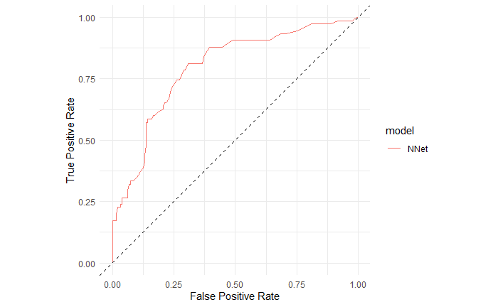

```r
data_for_roc <- map_df(
  seq(0, 1, 0.01),
  ~calculateFPRTPR(getConfusionMatrix(nnet_prediction, data_test, .x))
) %>% mutate(model = "NNet")

# recall our functions from lab "stacking"
plotROC <- function(performance_df) {
  ggplot(performance_df, aes(fpr, tpr, color = model)) +
    geom_path() +
    geom_abline(slope = 1, intercept = 0, linetype = "dashed") +
    coord_fixed() +
    labs(x = "False Positive Rate", y = "True Positive Rate")
}
plotROC(data_for_roc)
```

### Train nets with different starting points

`nnet` with different random initial seeds. (Default: 5 initial seeds, training takes 5x times with the same grid. Parameter `repeats` controls the number of seeds.) The final result comes from averaging.

```r
# takes a long time to run for the whole grid above so we just run for one parameter set
tune_grid <- expand.grid(size = 3, decay = 2.5, bag = FALSE)

set.seed(my_seed)
avnnet_model <- train(
  default ~ .,
  method = "avNNet",
  data = data_train,
  repeats = 5,
  trControl = train_control,
  tuneGrid = tune_grid,
  preProcess = c("center", "scale", "pca"),
  metric = "ROC",
  trace = FALSE
)
avnnet_model
```

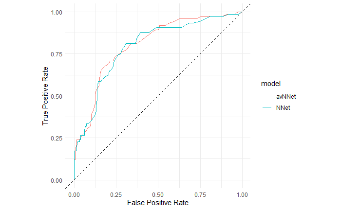

```r
avnnet_prediction <- predict(avnnet_model, newdata = data_test, type = "prob")$Yes
data_for_roc <- bind_rows(
  data_for_roc,
  map_df(
    seq(0, 1, 0.01),
    ~calculateFPRTPR(getConfusionMatrix(avnnet_prediction, data_test, .x))
  ) %>% mutate(model = "avNNet")
)
plotROC(data_for_roc)
```

## Deep learning with `h2o`

“Deep”: many layers of hidden units.

Note on estimation: when having large datasets, k-fold cross validation can become computationally burdensome, hence many times train/validation/test approach is used. (see answer on Quora by Yoshua Bengio, one of the originators of deep learning [here](https://www.quora.com/Is-cross-validation-heavily-used-in-deep-learning-or-is-it-too-expensive-to-be-used)). However, cross validation can still be used to tune some of the hyperparameters.

```r
library(h2o)
h2o.init()
```

```
 Connection successful!

R is connected to the H2O cluster:
    H2O cluster uptime:         2 days 20 hours
    H2O cluster timezone:       America/Sao_Paulo
    H2O data parsing timezone:  UTC
    H2O cluster version:        3.32.0.4
    H2O cluster version age:    1 month and 20 days
    H2O cluster name:           H2O_started_from_R_Samsung_hej473
    H2O cluster total nodes:    1
    H2O cluster total memory:   5.81 GB
    H2O cluster total cores:    8
    H2O cluster allowed cores:  8
    H2O cluster healthy:        TRUE
    H2O Connection ip:          localhost
    H2O Connection port:        54321
    H2O Connection proxy:       NA
    H2O Internal Security:      FALSE
    H2O API Extensions:         Amazon S3, Algos, AutoML, Core V3, TargetEncoder, Core V4
    R Version:                  R version 4.0.3 (2020-10-10)
```

```r
h2o.no_progress()
```

```r
data_split <- h2o.splitFrame(as.h2o(data), ratios = 0.75, seed = my_seed)
data_train_h2o <- as.h2o(data_train)
data_test_h2o <- as.h2o(data_test)

y <- "default"
X <- setdiff(names(data_train_h2o), y)
```

Validation frame: used to determine early stopping conditions. More on this later.

```r
dl_model <- h2o.deeplearning(
  x = X, y = y,
  training_frame = data_train_h2o,
  model_id = "DL_default",
  score_each_iteration =  TRUE,  # for the purpose of illustration
  seed = my_seed
)
dl_model
h2o.auc(h2o.performance(dl_model, data_test_h2o))
```

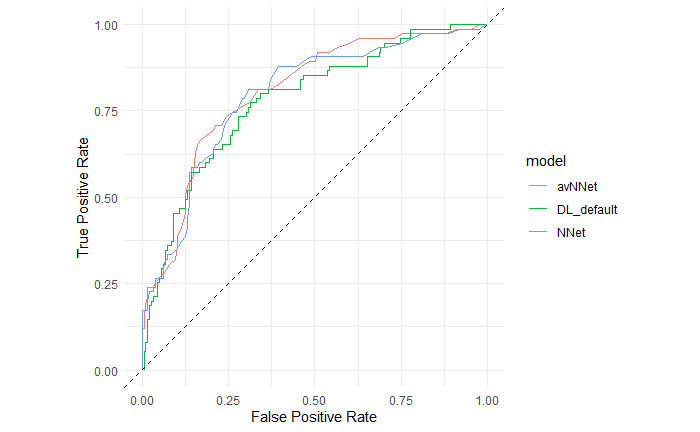

```r
# recall our function from lab "stacking"
getPerformanceMetrics <- function(model, newdata = NULL, xval = FALSE) {
  h2o.performance(model, newdata = newdata, xval = xval)@metrics$thresholds_and_metric_scores %>%
    as_tibble() %>%
    mutate(model = model@model_id)
}
dl_performance <- getPerformanceMetrics(dl_model, newdata = data_test_h2o)

bind_rows(
  data_for_roc,
  select(dl_performance, fpr, tpr, model)
) %>%
plotROC()
```

```r
h2o.scoreHistory(dl_model)
```

```
Scoring History:
```

|  | timestamp | duration | training_speed | epochs | iterations | samples | training_rmse | training_logloss | training_r2 | training_auc | training_pr_auc | training_lift | training_classification_error |
| --- | --- | --- | --- | --- | --- | --- | --- | --- | --- | --- | --- | --- | --- |
| 1 | 2021-03-22 13:54:00 | 0.000 sec | NA | 0.00000 | 0 | 0.000000 | NA | NA | NA | NA | NA | NA | NA |
| 2 | 2021-03-22 13:54:00 | 0.215 sec | 5952 obs/sec | 1.00000 | 1 | 750.000000 | 0.44217 | 0.68949 | 0.06898 | 0.79048 | 0.62360 | 2.91667 | 0.27733 |
| 3 | 2021-03-22 13:54:01 | 0.374 sec | 5905 obs/sec | 2.00000 | 2 | 1500.000000 | 0.45192 | 0.75288 | 0.02745 | 0.81202 | 0.64247 | 2.91667 | 0.25067 |
| 4 | 2021-03-22 13:54:01 | 0.519 sec | 6114 obs/sec | 3.00000 | 3 | 2250.000000 | 0.40526 | 0.58837 | 0.21793 | 0.85164 | 0.70559 | 3.33333 | 0.21333 |
| 5 | 2021-03-22 13:54:01 | 0.668 sec | 6172 obs/sec | 4.00000 | 4 | 3000.000000 | 0.68650 | 1.67602 | -1.24422 | 0.88395 | 0.78786 | 3.33333 | 0.16133 |
| 6 | 2021-03-22 13:54:01 | 0.794 sec | 6499 obs/sec | 5.00000 | 5 | 3750.000000 | 0.48377 | 0.68564 | -0.11444 | 0.92555 | 0.86184 | 3.33333 | 0.12533 |
| 7 | 2021-03-22 13:54:01 | 0.936 sec | 6646 obs/sec | 6.00000 | 6 | 4500.000000 | 0.30620 | 0.30391 | 0.55353 | 0.93435 | 0.87410 | 3.33333 | 0.12267 |
| 8 | 2021-03-22 13:54:01 | 1.079 sec | 6748 obs/sec | 7.00000 | 7 | 5250.000000 | 0.32877 | 0.33703 | 0.48529 | 0.94146 | 0.89546 | 3.33333 | 0.12667 |
| 9 | 2021-03-22 13:54:01 | 1.216 sec | 6787 obs/sec | 8.00000 | 8 | 6000.000000 | 0.28214 | 0.26253 | 0.62094 | 0.96893 | 0.94105 | 3.33333 | 0.07867 |
| 10 | 2021-03-22 13:54:02 | 1.351 sec | 6887 obs/sec | 9.00000 | 9 | 6750.000000 | 0.24924 | 0.20778 | 0.70420 | 0.97538 | 0.95039 | 3.33333 | 0.06800 |

[output cut: 2 more lines]

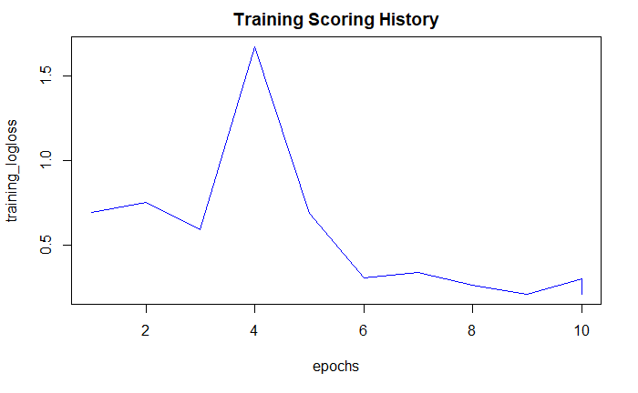

```r
plot(dl_model)
```

```r
dl_model@allparameters
```

There are lots of parameters that you can change, see `?h2o.deeplearning` and the [docs](http://docs.h2o.ai/h2o/latest-stable/h2o-docs/data-science/deep-learning.html). In the followings, we look at some selected parameters.

### Network structure and functional form

- `hidden`: neuron layer architecture: length of vector shows number of layers, number shows number of neurons within layer. The default: two hidden layers with 200-200 neurons. Makes sense to experiment with shallower but more neuron or with deeper and less neurons per layer architectures.

```r
shallow_small_model <- h2o.deeplearning(
  x = X, y = y,
  model_id = "DL_shallow_small",
  training_frame = data_train_h2o,
  validation_frame = data_test_h2o,
  hidden = c(10),
  seed = my_seed
)
```

```r
shallow_large_model <- h2o.deeplearning(
  x = X, y = y,
  model_id = "DL_shallow_large",
  training_frame = data_train_h2o,
  validation_frame = data_test_h2o,
  score_each_iteration = TRUE,
  hidden = c(512),
  seed = my_seed
)
```

```r
deep_small_model <- h2o.deeplearning(
  x = X, y = y,
  model_id = "DL_deep_small",
  training_frame = data_train_h2o,
  validation_frame = data_test_h2o,
  hidden = c(32, 32, 32, 32, 32),
  seed = my_seed
)
```

```r
deep_large_model <- h2o.deeplearning(
  x = X, y = y,
  model_id = "DL_deep_large",
  training_frame = data_train_h2o,
  validation_frame = data_test_h2o,
  hidden = c(100, 100, 100),
  seed = my_seed
)
```

```r
# compare performance on test set
compareAUC <- function(list_of_models) {
  map_df(
    list_of_models,
    ~tibble(model = .@model_id, auc = h2o.auc(h2o.performance(., newdata = data_test_h2o)))
  ) %>%
  arrange(-auc)
}

dl_models <- list(dl_model, shallow_small_model, shallow_large_model, deep_small_model, deep_large_model)
compareAUC(dl_models)
```

- `activation`: the nonlinear transformative function used. Default: Rectifier. “Tahn” stands for hyperbolic tangent that is very similar to sigmoid.

```r
tanh_model <- h2o.deeplearning(
  x = X, y = y,
  model_id = "DL_tanh",
  training_frame = data_train_h2o,
  validation_frame = data_test_h2o,
  hidden = c(512),
  activation = "Tanh",
  seed = my_seed
)
compareAUC(list(shallow_large_model, tanh_model))
```

### Training samples

- `epochs`: how many times will all training data points be used to adjust the model in the course of the optimization (defaults to 10). Note: early stopping is used by default so there is no guarantee that all epochs will be used.
- `mini_batch_size`: after how many training samples is the gradient update made (defaults to 1)

```r
more_epochs_model <- h2o.deeplearning(
  x = X, y = y,
  model_id = "DL_more_epochs",
  training_frame = data_train_h2o,
  validation_frame = data_test_h2o,
  hidden = c(512),
  epochs = 100,
  score_each_iteration = TRUE,
  seed = my_seed
)
```

```r
higher_batch_size_model <- h2o.deeplearning(
  x = X, y = y,
  model_id = "DL_higher_batch_size",
  training_frame = data_train_h2o,
  hidden = c(512),
  validation_frame = data_test_h2o,
  mini_batch_size = 10,
  seed = my_seed
)
compareAUC(list(shallow_large_model, more_epochs_model, higher_batch_size_model))
```

### Regularization

You have multiple ways to regularize in a neural network. One is *“dropout”*, that “approximates training a large number of neural networks with different architectures in parallel” [source](https://machinelearningmastery.com/dropout-for-regularizing-deep-neural-networks/). Some of the nodes are randomly ignored or “dropped out” during training. Another method is to apply *penalty terms* as we did with penalized linear regressions. You can also control when the iterative optimization process should stop - with *early stopping* you can also prevent overfitting.

- `hidden_dropout_ratios`: with how large probability will neurons be left out of the model at a step (defaults to 0.5). Have to use “WithDropout” activation to use dropout.

```r
dropout_model <- h2o.deeplearning(
  x = X, y = y,
  model_id = "DL_dropout",
  training_frame = data_train_h2o,
  validation_frame = data_test_h2o,
  hidden = 512,
  activation = "RectifierWithDropout",
  hidden_dropout_ratios = 0.6,
  seed = my_seed
)
```

- `input_dropout_ratio`: drop some input features randomly (defaults to 0).

```r
input_dropout_model <- h2o.deeplearning(
  x = X, y = y,
  model_id = "DL_input_dropout",
  training_frame = data_train_h2o,
  validation_frame = data_test_h2o,
  hidden = 512 ,
  input_dropout_ratio = 0.1,
  seed = my_seed
)
compareAUC(list(shallow_large_model, dropout_model, input_dropout_model))
```

| model | auc |
| --- | --- |
| DL_shallow_large | 0.8150857 |
| DL_dropout | 0.8083810 |
| DL_input_dropout | 0.7959619 |

For more on dropout, see the original paper [here](http://jmlr.org/papers/volume15/srivastava14a.old/srivastava14a.pdf).

- `l1`, `l2`: weight on $L1$ (lasso), $L2$ (ridge) penalty terms

```r
regularized_model <- h2o.deeplearning(
  x = X, y = y,
  model_id = "DL_regularized",
  training_frame = data_train_h2o,
   validation_frame = data_test_h2o,
  hidden = 512,
  l1 = 0.01,
  l2 = 0.01,
  seed = my_seed
)
compareAUC(list(shallow_large_model, regularized_model))
```

| model | auc |
| --- | --- |
| DL_regularized | 0.8191238 |
| DL_shallow_large | 0.8150857 |

Training constantly tracks validation frame performance. Early stopping is enabled by default but can be tuned when to stop. This, again, is to prevent overfitting. (If you don’t supply a `validation_frame`, early stopping still works but based on metrics calculated from the training set, so it may not be as informative for out-of-sample performance.)

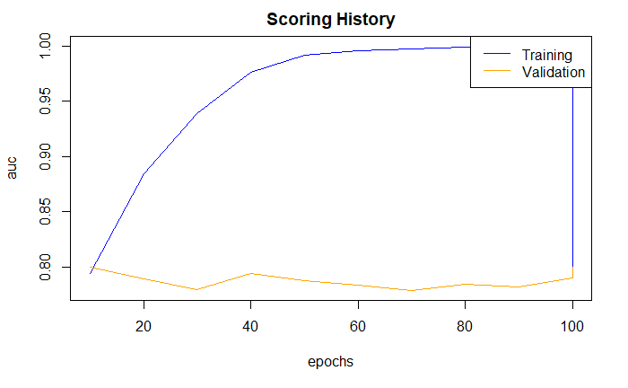

```r
early_stopping_model <- h2o.deeplearning(
  x = X, y = y,
  model_id = "DL_early_stopping",
  training_frame = data_train_h2o,
  validation_frame = data_test_h2o,
  hidden = c(512),
  score_each_iteration = TRUE,
  epochs = 100,
  stopping_rounds = 10,
  stopping_metric = "AUC",
  stopping_tolerance = 0.01,
  seed = my_seed
)
plot(early_stopping_model, metric = "AUC", xval = TRUE)
```

```r
compareAUC(list(shallow_large_model, early_stopping_model))
```

| model | auc |
| --- | --- |
| DL_shallow_large | 0.8150857 |
| DL_early_stopping | 0.7995429 |

## Helpful resources to deepen understanding

Videos of 3 Blue 1 Brown are awesome. Start [here](https://www.youtube.com/watch?v=aircAruvnKk&t=).